# Results classroom PGG

Jantsje Mol

23/9/2020

## Session 1: one shot PGG

*Monday November 2nd, 2020*

In this game, 162 students participated.

- Number of rounds: 1
- Group size: 3
- Multiplication factor: 1.6
- Punishment: 0
- Threshold: 0
- Chat: 0

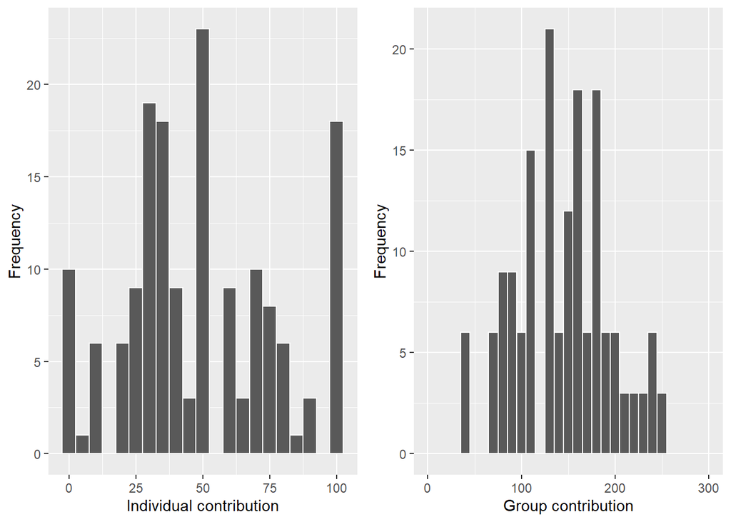

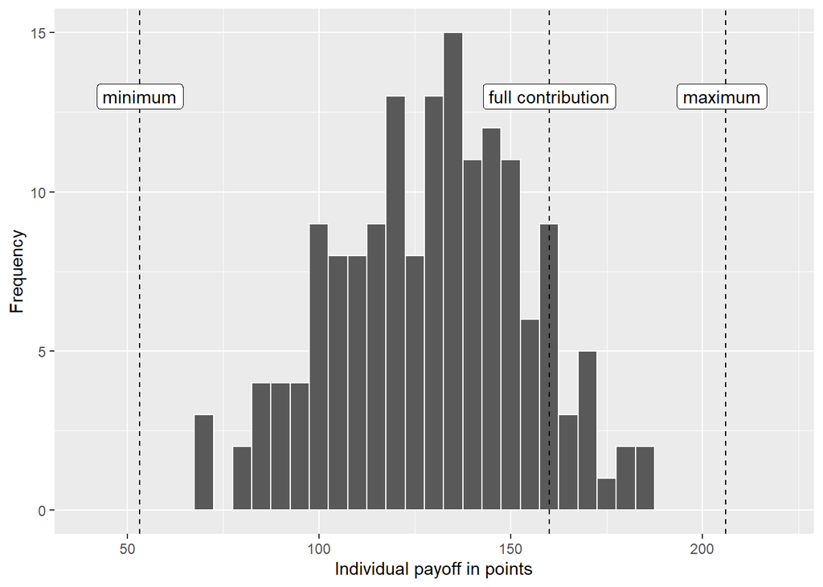

## Session 2: ten rounds PGG

*Wednesday November 11th, 2020*

In this game, 139 students participated.

- Number of rounds: 10
- Group size: 3
- Multiplication factor: 1.6
- Punishment: 0
- Threshold: 0
- Chat: 0

## Session 3: ten rounds PGG + threshold

*Thursday November 19th, 2020*

In this game, 115 students participated.

- Number of rounds: 10
- Group size: 3
- Multiplication factor: 1.6
- Punishment: 0
- Threshold: 150
- Chat: 0